# Spatial Inequalities in Street-Tree Ecological Quality across New York City

This notebook implements the full data processing and analysis pipeline for the midterm submission.

**Research Questions:**

- **RQ1:** What spatial inequalities and clustering patterns characterize street-tree health, structural attributes, and species diversity across NYC?
- **RQ2:** How do street-tree ecological quality indicators associate with socioeconomic vulnerability, built-environment intensity (including 2D urban morphology and landscape configuration), and green infrastructure supply?
- **RQ3:** Where do multiple disadvantages (low tree quality + high social vulnerability + high built density / fragmented greenery) overlap, and can we identify priority intervention areas?

## 0. Setup

```python
import os
import pandas as pd
import geopandas as gpd
import numpy as np
import matplotlib.pyplot as plt
import seaborn as sns
import rasterio
from rasterio.mask import mask as rio_mask
from rasterstats import zonal_stats
from scipy.stats import entropy, pearsonr
from scipy.ndimage import label, binary_dilation
from shapely.geometry import mapping
from shapely import wkt
import missingno as msno
import warnings
warnings.filterwarnings('ignore')

# Paths (relative to notebooks/)
RAW = '../data/raw/'
PROCESSED = '../data/processed/'
VIS = '../visualizations/'
os.makedirs(PROCESSED, exist_ok=True)
os.makedirs(VIS, exist_ok=True)

plt.rcParams.update({
    'figure.dpi': 150,
    'font.family': 'sans-serif',
    'font.size': 10,
    'axes.titlesize': 12,
    'axes.labelsize': 10,
})

# Borough color palette (used across all figures)
BOROUGH_COLORS = {
    'Manhattan': '#e41a1c', 'Brooklyn': '#377eb8', 'Queens': '#4daf4a',
    'Bronx': '#ff7f00', 'Staten Island': '#984ea3'
}

print('All imports successful.')
```

```
All imports successful.
```

## 1. Census Tract Boundaries

**Data source:** 2020 TIGER/Line Census Tracts for New York State, downloaded from the U.S. Census Bureau.  
**Coverage:** Five NYC counties (FIPS 005=Bronx, 047=Brooklyn, 061=Manhattan, 081=Queens, 085=Staten Island).  
**Granularity:** Polygon; one record per Census Tract.  
**Format:** Shapefile (.shp).  
**Source:** https://www2.census.gov/geo/tiger/TIGER2020/TRACT/

Census Tracts serve as the primary spatial unit because they (1) align directly with ACS socioeconomic estimates, (2) are the standard unit for environmental justice analyses, and (3) provide sufficient spatial resolution (~2,300 tracts in NYC).

```python
tracts_all = gpd.read_file(RAW + 'census_tracts/tl_2020_36_tract.shp')
nyc_fips = ['005', '047', '061', '081', '085']
tracts = tracts_all[tracts_all['COUNTYFP'].isin(nyc_fips)].copy()
tracts = tracts.to_crs(epsg=26918)  # UTM 18N for accurate area calculations
tracts['area_m2'] = tracts.geometry.area
tracts['area_km2'] = tracts['area_m2'] / 1e6

borough_map = {'005': 'Bronx', '047': 'Brooklyn', '061': 'Manhattan',
               '081': 'Queens', '085': 'Staten Island'}
tracts['borough'] = tracts['COUNTYFP'].map(borough_map)

tracts.to_file(PROCESSED + 'nyc_tracts.gpkg', driver='GPKG')
print(f'NYC Census Tracts: {len(tracts)}')
print(tracts['borough'].value_counts().to_string())
```

```
NYC Census Tracts: 2327
borough
Brooklyn         805
Queens           725
Bronx            361
Manhattan        310
Staten Island    126
```

## 2. Street Tree Census — Cleaning and Tract-Level Aggregation

**Data source:** TreesCount! 2015–2016 Street Tree Census from NYC Open Data.  
**Coverage:** All five NYC boroughs; collected 2015–2016.  
**Granularity:** Point; one record per individual street tree (683,788 raw records).  
**Type:** Quantitative (DBH) and categorical (health status, species).  
**Format:** CSV with latitude/longitude coordinates.  
**Source:** https://data.cityofnewyork.us/Environment/2015-Street-Tree-Census-Tree-Data/uvpi-gqnh

**Cleaning steps:**

1. Filter to `status == "Alive"` (exclude Dead and Stump records)
2. Remove records with missing or zero coordinates
3. Cap DBH outliers (> 100 inches set to NaN)
4. Encode health numerically: Good=3, Fair=2, Poor=1
5. Spatial join to Census Tracts
6. Aggregate to tract level: count, density, mean DBH, health index, Shannon diversity

```python
trees_raw = pd.read_csv(RAW + 'tree_census_2015.csv', low_memory=False)
print(f'Raw records: {len(trees_raw):,}')
print(f'\nStatus distribution:\n{trees_raw["status"].value_counts().to_string()}')
print(f'\nHealth distribution (Alive only):')
print(trees_raw[trees_raw['status'] == 'Alive']['health'].value_counts().to_string())
```

```
Raw records: 683,788

Status distribution:
status
Alive    652173
Stump     17654
Dead      13961

Health distribution (Alive only):
health
Good    528850
Fair     96504
Poor     26818
```

```python
# Step 1: Filter to alive trees
trees = trees_raw[trees_raw['status'] == 'Alive'].copy()
print(f'After alive filter: {len(trees):,} ({len(trees)/len(trees_raw)*100:.1f}%)')

# Step 2: Remove missing/zero coordinates
before = len(trees)
trees = trees.dropna(subset=['latitude', 'longitude'])
trees = trees[(trees['latitude'] != 0) & (trees['longitude'] != 0)]
print(f'After coordinate cleaning: {len(trees):,} (removed {before - len(trees)})')

# Step 3: Cap DBH outliers
outlier_mask = trees['tree_dbh'] > 100
print(f'DBH outliers (>100 in): {outlier_mask.sum()}')
trees.loc[outlier_mask, 'tree_dbh'] = np.nan

# Step 4: Encode health numerically
health_map = {'Good': 3, 'Fair': 2, 'Poor': 1}
trees['health_score'] = trees['health'].map(health_map)
print(f'Health score mapped: {trees["health_score"].notna().sum():,} valid')
print(f'\nCleaned dataset: {len(trees):,} alive street trees')
```

```
After alive filter: 652,173 (95.4%)
After coordinate cleaning: 652,173 (removed 0)
DBH outliers (>100 in): 67
Health score mapped: 652,172 valid

Cleaned dataset: 652,173 alive street trees
```

```python
# Step 5: Convert to GeoDataFrame and spatial join to tracts
trees_gdf = gpd.GeoDataFrame(
    trees,
    geometry=gpd.points_from_xy(trees['longitude'], trees['latitude']),
    crs='EPSG:4326'
).to_crs(epsg=26918)

trees_joined = gpd.sjoin(
    trees_gdf, tracts[['GEOID', 'borough', 'geometry']],
    how='inner', predicate='within'
)
print(f'Trees joined to tracts: {len(trees_joined):,}')

# Rename borough column if spatial join created suffix
if 'borough_left' in trees_joined.columns:
    trees_joined = trees_joined.drop(columns=['borough_left'], errors='ignore')
if 'borough_right' in trees_joined.columns:
    trees_joined = trees_joined.rename(columns={'borough_right': 'borough_sj'})
# Ensure a clean 'borough' column from the join
if 'borough_sj' in trees_joined.columns and 'borough' not in trees_joined.columns:
    trees_joined = trees_joined.rename(columns={'borough_sj': 'borough'})

trees_joined.drop(columns=['geometry']).to_csv(PROCESSED + 'trees_cleaned.csv', index=False)
print('Saved trees_cleaned.csv')
```

```
Trees joined to tracts: 652,045
Saved trees_cleaned.csv
```

```python
# Step 6: Aggregate to tract level
def shannon_diversity(species_series):
    """Compute Shannon diversity index H' from a series of species names."""
    counts = species_series.value_counts()
    proportions = counts / counts.sum()
    return entropy(proportions, base=np.e)

# Determine which borough column to use
boro_col = 'borough' if 'borough' in trees_joined.columns else 'borough_right'

tract_trees = trees_joined.groupby('GEOID').agg(
    tree_count=('tree_id', 'count'),
    mean_dbh=('tree_dbh', 'mean'),
    median_dbh=('tree_dbh', 'median'),
    health_index=('health_score', 'mean'),
    pct_good=('health', lambda x: (x == 'Good').mean() * 100),
    pct_fair=('health', lambda x: (x == 'Fair').mean() * 100),
    pct_poor=('health', lambda x: (x == 'Poor').mean() * 100),
    species_count=('spc_latin', 'nunique'),
    species_diversity=('spc_latin', shannon_diversity),
    dominant_species=('spc_common', lambda x: x.value_counts().index[0] if len(x) > 0 else np.nan),
).reset_index()

tract_trees = tract_trees.merge(tracts[['GEOID', 'area_km2']], on='GEOID')
tract_trees['tree_density'] = tract_trees['tree_count'] / tract_trees['area_km2']

tract_trees.to_csv(PROCESSED + 'trees_by_tract.csv', index=False)
print(f'Tract-level tree indicators: {len(tract_trees)} tracts')
tract_trees[['tree_count', 'mean_dbh', 'health_index', 'species_diversity', 'tree_density']].describe().round(2)
```

```
Tract-level tree indicators: 2306 tracts
```

|  | tree_count | mean_dbh | health_index | species_diversity | tree_density |
| --- | --- | --- | --- | --- | --- |
| count | 2306.00 | 2306.00 | 2306.00 | 2306.00 | 2306.00 |
| mean | 282.76 | 11.46 | 2.76 | 2.63 | 1102.92 |
| std | 274.04 | 3.51 | 0.14 | 0.51 | 519.30 |
| min | 2.00 | 2.95 | 1.25 | 0.00 | 0.85 |
| 25% | 147.00 | 8.82 | 2.69 | 2.41 | 768.66 |
| 50% | 215.00 | 11.14 | 2.78 | 2.71 | 1122.40 |
| 75% | 314.75 | 13.77 | 2.85 | 2.96 | 1445.78 |
| max | 3143.00 | 27.43 | 3.00 | 3.64 | 2887.91 |

### Dominant Species Ecological Profile

NYC's top 15 street tree species and their ecological characteristics, compiled from USDA plant databases and urban forestry literature.

```python
top_species = trees_joined['spc_common'].value_counts().head(15)
print('Top 15 street tree species in NYC:')
for i, (sp, cnt) in enumerate(top_species.items(), 1):
    pct = cnt / len(trees_joined) * 100
    print(f'  {i:2d}. {sp:<30s} {cnt:>7,}  ({pct:.1f}%)')

species_profiles = {
    'London planetree':  {'shade': 'High',     'heat_tol': 'High',     'pollution_tol': 'High',     'stormwater': 'High',     'native': False},
    'honeylocust':       {'shade': 'Moderate', 'heat_tol': 'High',     'pollution_tol': 'High',     'stormwater': 'Moderate', 'native': True},
    'Callery pear':      {'shade': 'Moderate', 'heat_tol': 'Moderate', 'pollution_tol': 'High',     'stormwater': 'Low',      'native': False},
    'pin oak':           {'shade': 'High',     'heat_tol': 'Moderate', 'pollution_tol': 'Moderate', 'stormwater': 'High',     'native': True},
    'Norway maple':      {'shade': 'High',     'heat_tol': 'Moderate', 'pollution_tol': 'High',     'stormwater': 'Moderate', 'native': False},
    'littleleaf linden': {'shade': 'High',     'heat_tol': 'Moderate', 'pollution_tol': 'Moderate', 'stormwater': 'Moderate', 'native': False},
    'cherry':            {'shade': 'Low',      'heat_tol': 'Low',      'pollution_tol': 'Low',      'stormwater': 'Low',      'native': False},
    'Japanese zelkova':  {'shade': 'High',     'heat_tol': 'High',     'pollution_tol': 'High',     'stormwater': 'Moderate', 'native': False},
    'ginkgo':            {'shade': 'Moderate', 'heat_tol': 'High',     'pollution_tol': 'High',     'stormwater': 'Low',      'native': False},
    'red maple':         {'shade': 'High',     'heat_tol': 'Moderate', 'pollution_tol': 'Moderate', 'stormwater': 'High',     'native': True},
}
sp_df = pd.DataFrame(species_profiles).T
sp_df.index.name = 'species'
sp_df.to_csv(PROCESSED + 'species_profiles.csv')
sp_df
```

```
Top 15 street tree species in NYC:
   1. London planetree                87,010  (13.3%)
   2. honeylocust                     64,259  (9.9%)
   3. Callery pear                    58,907  (9.0%)
   4. pin oak                         53,173  (8.2%)
   5. Norway maple                    34,182  (5.2%)
   6. littleleaf linden               29,734  (4.6%)
   7. cherry                          29,275  (4.5%)
   8. Japanese zelkova                29,253  (4.5%)
   9. ginkgo                          21,023  (3.2%)
  10. Sophora                         19,337  (3.0%)
  11. red maple                       17,244  (2.6%)
  12. green ash                       16,243  (2.5%)
  13. American linden                 13,530  (2.1%)
  14. silver maple                    12,274  (1.9%)
  15. sweetgum                        10,656  (1.6%)
```

| species | shade | heat_tol | pollution_tol | stormwater | native |
| --- | --- | --- | --- | --- | --- |
| London planetree | High | High | High | High | False |
| honeylocust | Moderate | High | High | Moderate | True |
| Callery pear | Moderate | Moderate | High | Low | False |
| pin oak | High | Moderate | Moderate | High | True |
| Norway maple | High | Moderate | High | Moderate | False |
| littleleaf linden | High | Moderate | Moderate | Moderate | False |
| cherry | Low | Low | Low | Low | False |
| Japanese zelkova | High | High | High | Moderate | False |
| ginkgo | Moderate | High | High | Low | False |
| red maple | High | Moderate | Moderate | High | True |

## 3. UrbanWatch Land Cover — Classification and Zonal Statistics

**Data source:** UrbanWatch 1-meter resolution urban land cover classification (University of Vermont / UNC Charlotte).  
**Coverage:** New York City extent.  
**Granularity:** Raster; 1 m² per pixel; 42,000 × 46,674 pixels.  
**Type:** Categorical (9 land cover classes encoded as RGB triplets).  
**Format:** GeoTIFF, 3-band RGB, EPSG:26918.  
**Source:** https://urbanwatch.charlotte.edu/  
**Citation:** Zhang et al. (2022). Remote Sensing of Environment, 278, 113106.

**Processing:**

1. Decode 3-band RGB into a single-band classified raster (9 classes + nodata)
2. Compute per-tract zonal statistics: proportion of each land cover class (PLAND)
3. Derive composite indicators: impervious ratio, pervious ratio

```python
# UrbanWatch RGB-to-class mapping
UW_CLASS_MAP = {
    (255,   0,   0): 1,   # Building
    (133, 133, 133): 2,   # Road
    (255,   0, 192): 3,   # Parking lot
    ( 34, 139,  34): 4,   # Tree canopy
    (128, 236, 104): 5,   # Grass/shrub
    (  0,   0, 255): 6,   # Water
    (128,   0,   0): 7,   # Agriculture
    (255, 255, 255): 8,   # Barren
}
UW_CLASS_NAMES = {
    1: 'building', 2: 'road', 3: 'parking', 4: 'tree_canopy',
    5: 'grass_shrub', 6: 'water', 7: 'agriculture', 8: 'barren'
}
print('UrbanWatch class mapping:')
for rgb, cls_id in UW_CLASS_MAP.items():
    print(f'  RGB{rgb} -> {cls_id}: {UW_CLASS_NAMES[cls_id]}')
```

```
UrbanWatch class mapping:
  RGB(255, 0, 0) -> 1: building
  RGB(133, 133, 133) -> 2: road
  RGB(255, 0, 192) -> 3: parking
  RGB(34, 139, 34) -> 4: tree_canopy
  RGB(128, 236, 104) -> 5: grass_shrub
  RGB(0, 0, 255) -> 6: water
  RGB(128, 0, 0) -> 7: agriculture
  RGB(255, 255, 255) -> 8: barren
```

```python
# Convert 3-band RGB raster to single-band classified raster
classified_path = PROCESSED + 'urbanwatch_classified.tif'

if not os.path.exists(classified_path):
    print('Converting RGB raster to classified (this takes ~1 minute)...')
    with rasterio.open(RAW + 'NYC_urbanwatch_merged.tif') as src:
        r, g, b = src.read(1), src.read(2), src.read(3)
        classified = np.zeros(r.shape, dtype=np.uint8)
        for (rv, gv, bv), cls_id in UW_CLASS_MAP.items():
            mask = (r == rv) & (g == gv) & (b == bv)
            classified[mask] = cls_id
            print(f'  Class {cls_id} ({UW_CLASS_NAMES[cls_id]}): {mask.sum():,} pixels')
        profile = src.profile.copy()
        profile.update(count=1, dtype='uint8', nodata=0)
        with rasterio.open(classified_path, 'w', **profile) as dst:
            dst.write(classified, 1)
    total_valid = (classified > 0).sum()
    print(f'\nTotal valid pixels: {total_valid:,}')
    print('Classified raster saved.')
else:
    print(f'Classified raster already exists: {classified_path}')
```

```
Classified raster already exists: ../data/processed/urbanwatch_classified.tif
```

```python
# Zonal statistics: count of each class per tract
tracts_utm = tracts.to_crs(epsg=26918)

print('Computing zonal statistics (takes ~2 minutes)...')
lc_stats = zonal_stats(tracts_utm, classified_path, categorical=True, nodata=0)
lc_df = pd.DataFrame(lc_stats).fillna(0)
lc_df['GEOID'] = tracts_utm['GEOID'].values

# Sum only valid class columns (integers > 0) for total pixel count
class_cols = [c for c in lc_df.columns if isinstance(c, (int, float)) and c > 0]
lc_df['total_pixels'] = lc_df[class_cols].sum(axis=1)

# Compute PLAND for each class
for cls_id, cls_name in UW_CLASS_NAMES.items():
    if cls_id in lc_df.columns:
        lc_df[f'pland_{cls_name}'] = lc_df[cls_id] / lc_df['total_pixels'] * 100
    else:
        lc_df[f'pland_{cls_name}'] = 0.0

# Composite indicators
lc_df['pland_impervious'] = lc_df['pland_building'] + lc_df['pland_road'] + lc_df['pland_parking']
lc_df['pland_pervious'] = lc_df['pland_tree_canopy'] + lc_df['pland_grass_shrub'] + lc_df['pland_water'] + lc_df['pland_agriculture']

pland_cols = [c for c in lc_df.columns if isinstance(c, str) and c.startswith('pland_')]
tract_lc = lc_df[['GEOID'] + pland_cols].copy()
tract_lc.to_csv(PROCESSED + 'landcover_by_tract.csv', index=False)
print(f'Land cover saved: {len(tract_lc)} tracts, {len(pland_cols)} indicators')
tract_lc[pland_cols].describe().round(2)
```

```
Computing zonal statistics (takes ~2 minutes)...
Land cover saved: 2327 tracts, 10 indicators
```

|  | pland_building | pland_road | pland_parking | pland_tree_canopy | pland_grass_shrub | pland_water | pland_agriculture | pland_barren | pland_impervious | pland_pervious |
| --- | --- | --- | --- | --- | --- | --- | --- | --- | --- | --- |
| count | 2320.00 | 2320.00 | 2320.00 | 2320.00 | 2320.00 | 2320.00 | 2320.00 | 2320.00 | 2320.00 | 2320.00 |
| mean | 37.35 | 26.50 | 3.11 | 27.41 | 4.95 | 0.34 | 0.17 | 0.16 | 66.96 | 32.88 |
| std | 13.35 | 7.15 | 5.26 | 12.20 | 7.56 | 2.24 | 1.55 | 0.60 | 16.28 | 16.29 |
| min | 0.00 | 1.37 | 0.00 | 1.36 | 0.00 | 0.00 | 0.00 | 0.00 | 1.37 | 1.52 |
| 25% | 28.93 | 22.45 | 0.30 | 19.64 | 0.75 | 0.00 | 0.00 | 0.00 | 59.69 | 21.92 |
| 50% | 39.07 | 26.58 | 1.37 | 26.03 | 2.22 | 0.00 | 0.00 | 0.00 | 70.14 | 29.79 |
| 75% | 46.95 | 30.65 | 3.49 | 33.36 | 6.53 | 0.01 | 0.01 | 0.01 | 77.92 | 40.16 |
| max | 73.22 | 65.86 | 62.06 | 88.09 | 83.77 | 61.65 | 48.27 | 6.97 | 97.46 | 98.63 |

## 4. NYC Building Footprints — Tract-Level Aggregation

**Data source:** NYC Building Footprints (NYC DoITT / Open Data).  
**Coverage:** All five boroughs; ~1.08 million buildings.  
**Granularity:** Polygon; one record per building footprint.  
**Type:** Quantitative (`height_roof` in feet).  
**Format:** GeoPackage (.gpkg), EPSG:4326.  
**Source:** https://data.cityofnewyork.us/Housing-Development/Building-Footprints/nqwf-w8eh

**Processing:**

1. Reproject to UTM 18N; compute footprint area from geometry
2. Convert `height_roof` from feet to meters
3. Spatial join to Census Tracts via representative points
4. Aggregate: mean/median/max height, building count, coverage ratio, density

```python
print('Loading building footprints (~1 minute)...')
buildings = gpd.read_file(RAW + 'NYC_buildings.gpkg')
print(f'Raw buildings: {len(buildings):,}')
print(f'CRS: {buildings.crs}')
print(f'\nheight_roof stats (feet):\n{buildings["height_roof"].describe().to_string()}')
```

```
Loading building footprints (~1 minute)...
Raw buildings: 1,082,289
CRS: EPSG:4326

height_roof stats (feet):
count    1.082289e+06
mean     2.779539e+01
std      2.231814e+01
min      0.000000e+00
25%      1.855000e+01
50%      2.615000e+01
75%      3.118000e+01
max      1.550000e+03
```

```python
buildings = buildings.to_crs(epsg=26918)
buildings['footprint_m2'] = buildings.geometry.area
buildings['height_m'] = buildings['height_roof'] * 0.3048  # feet to meters

# Spatial join via representative points to avoid boundary issues
print('Spatial joining buildings to tracts...')
buildings['rep_point'] = buildings.geometry.representative_point()
bldg_points = buildings.set_geometry('rep_point')
bldg_joined = gpd.sjoin(
    bldg_points, tracts_utm[['GEOID', 'area_m2', 'geometry']],
    how='inner', predicate='within'
)
print(f'Buildings joined: {len(bldg_joined):,}')

tract_bldg = bldg_joined.groupby('GEOID').agg(
    building_count=('height_m', 'count'),
    mean_height_m=('height_m', 'mean'),
    median_height_m=('height_m', 'median'),
    max_height_m=('height_m', 'max'),
    total_footprint_m2=('footprint_m2', 'sum'),
    tract_area_m2=('area_m2', 'first'),
).reset_index()
tract_bldg['building_coverage'] = tract_bldg['total_footprint_m2'] / tract_bldg['tract_area_m2'] * 100
tract_bldg['building_density'] = tract_bldg['building_count'] / (tract_bldg['tract_area_m2'] / 1e6)
tract_bldg = tract_bldg.drop(columns=['tract_area_m2'])

tract_bldg.to_csv(PROCESSED + 'buildings_by_tract.csv', index=False)
print(f'Building indicators saved: {len(tract_bldg)} tracts')
tract_bldg.describe().round(2)
```

```
Spatial joining buildings to tracts...
Buildings joined: 1,082,092
Building indicators saved: 2322 tracts
```

|  | building_count | mean_height_m | median_height_m | max_height_m | total_footprint_m2 | building_coverage | building_density |
| --- | --- | --- | --- | --- | --- | --- | --- |
| count | 2322.00 | 2322.00 | 2322.00 | 2322.00 | 2322.00 | 2322.00 | 2322.00 |
| mean | 466.02 | 11.63 | 10.76 | 41.26 | 69771.67 | 28.47 | 1881.89 |
| std | 411.78 | 9.14 | 7.45 | 44.13 | 52885.73 | 11.64 | 1203.06 |
| min | 1.00 | 3.59 | 3.35 | 4.11 | 165.51 | 0.01 | 0.50 |
| 25% | 171.25 | 7.14 | 7.57 | 19.20 | 43670.11 | 21.45 | 879.43 |
| 50% | 388.00 | 8.33 | 8.33 | 25.91 | 58465.07 | 29.60 | 1852.42 |
| 75% | 603.75 | 12.18 | 10.67 | 46.94 | 78230.55 | 36.38 | 2777.90 |
| max | 3233.00 | 97.78 | 101.38 | 472.44 | 1008078.50 | 60.23 | 5366.84 |

## 5. PLUTO — Built Environment Indicators

**Data source:** Primary Land Use Tax Lot Output (PLUTO) v25.4, NYC Department of City Planning.  
**Coverage:** All five boroughs; 858,644 tax lots.  
**Granularity:** Tabular; one record per tax lot with built-in Census Tract identifier (`bct2020`).  
**Type:** Mixed (quantitative: FAR, floors, lot area; categorical: land use).  
**Format:** CSV.  
**Source:** https://www.nyc.gov/site/planning/data-maps/open-data/dwn-pluto-mappluto.page

**Processing:**

1. Construct 11-digit GEOID from `borocode` + `bct2020`
2. Aggregate to tract level: mean FAR, mean floors, median year built, dominant land use

```python
pluto_cols = ['borough', 'block', 'lot', 'bct2020', 'borocode', 'landuse',
              'lotarea', 'bldgarea', 'numfloors', 'yearbuilt', 'builtfar',
              'unitsres', 'unitstotal', 'assesstot', 'latitude', 'longitude']
pluto = pd.read_csv(RAW + 'pluto_25v4.csv', usecols=pluto_cols, low_memory=False)
print(f'Raw PLUTO lots: {len(pluto):,}')

# Construct GEOID: state(36) + county(3) + tract(6)
boro_to_county = {1: '061', 2: '005', 3: '047', 4: '081', 5: '085'}
pluto = pluto.dropna(subset=['bct2020', 'borocode'])
pluto['borocode'] = pluto['borocode'].astype(int)
pluto['county_fips'] = pluto['borocode'].map(boro_to_county)
pluto['tract_code'] = pluto['bct2020'].astype(int).astype(str).str[1:]  # remove borocode prefix
pluto['GEOID'] = '36' + pluto['county_fips'] + pluto['tract_code'].str.zfill(6)

tract_pluto = pluto.groupby('GEOID').agg(
    mean_far=('builtfar', 'mean'),
    mean_floors=('numfloors', 'mean'),
    median_yearbuilt=('yearbuilt', lambda x: x[x > 0].median()),
    total_lotarea=('lotarea', 'sum'),
    total_bldgarea=('bldgarea', 'sum'),
    total_res_units=('unitsres', 'sum'),
    lot_count=('lotarea', 'count'),
    dominant_landuse=('landuse', lambda x: str(int(x.mode().iloc[0])).zfill(2) if len(x.mode()) > 0 else np.nan),
).reset_index()
tract_pluto['bldg_to_lot_ratio'] = tract_pluto['total_bldgarea'] / tract_pluto['total_lotarea'].replace(0, np.nan)

tract_pluto.to_csv(PROCESSED + 'pluto_by_tract.csv', index=False)
print(f'PLUTO indicators saved: {len(tract_pluto)} tracts')
tract_pluto[['mean_far', 'mean_floors', 'median_yearbuilt', 'bldg_to_lot_ratio']].describe().round(2)
```

```
Raw PLUTO lots: 858,644
PLUTO indicators saved: 2329 tracts
```

|  | mean_far | mean_floors | median_yearbuilt | bldg_to_lot_ratio |
| --- | --- | --- | --- | --- |
| count | 2329.00 | 2310.00 | 2313.00 | 2329.00 |
| mean | 1.59 | 3.40 | 1933.75 | 1.74 |
| std | 1.61 | 3.07 | 22.63 | 2.01 |
| min | 0.00 | 1.00 | 1849.00 | 0.00 |
| 25% | 0.71 | 2.10 | 1920.00 | 0.65 |
| 50% | 1.12 | 2.41 | 1930.00 | 1.18 |
| 75% | 1.80 | 3.33 | 1945.00 | 2.01 |
| max | 16.58 | 44.00 | 2014.50 | 17.46 |

## 6. NYC Parks Properties — Green Space Supply

**Data source:** NYC Parks Properties, NYC Department of Parks & Recreation.  
**Coverage:** All five boroughs; 2,058 park property polygons.  
**Granularity:** Polygon; one record per park property.  
**Format:** CSV with WKT `multipolygon` geometry column.  
**Source:** https://data.cityofnewyork.us/Recreation/Parks-Properties/enfh-gkve

**Processing:**

1. Parse WKT geometry from `multipolygon` column
2. Intersect with Census Tracts
3. Compute park area ratio (park area / tract area) per tract

```python
parks_raw = pd.read_csv(RAW + 'nyc_parks.csv', low_memory=False)
print(f'Parks records: {len(parks_raw)}')

# Identify and parse geometry column
geom_cols = [c for c in parks_raw.columns if 'multipolygon' in c.lower() or 'polygon' in c.lower() or 'geom' in c.lower()]
print(f'Geometry columns found: {geom_cols}')

geom_col = geom_cols[0]  # 'multipolygon'
parks_raw['geometry'] = parks_raw[geom_col].apply(lambda x: wkt.loads(x) if pd.notna(x) else None)
parks_gdf = gpd.GeoDataFrame(parks_raw, geometry='geometry', crs='EPSG:4326')
parks_gdf = parks_gdf[parks_gdf.geometry.notna()].to_crs(epsg=26918)
print(f'Parsed {len(parks_gdf)} park geometries')

# Intersect with tracts
parks_overlay = gpd.overlay(
    parks_gdf[['geometry']], tracts_utm[['GEOID', 'geometry', 'area_m2']],
    how='intersection'
)
parks_overlay['intersect_area'] = parks_overlay.geometry.area

tract_parks = parks_overlay.groupby('GEOID').agg(
    park_area_m2=('intersect_area', 'sum'),
    park_count=('intersect_area', 'count'),
).reset_index()
tract_parks = tract_parks.merge(tracts[['GEOID', 'area_m2']], on='GEOID')
tract_parks['park_area_pct'] = tract_parks['park_area_m2'] / tract_parks['area_m2'] * 100
tract_parks = tract_parks.drop(columns=['area_m2'])

tract_parks.to_csv(PROCESSED + 'parks_by_tract.csv', index=False)
print(f'Parks saved: {len(tract_parks)} tracts with park coverage')
tract_parks.describe().round(2)
```

```
Parks records: 2058
Geometry columns found: ['multipolygon']
Parsed 2058 park geometries
Parks saved: 1354 tracts with park coverage
```

|  | park_area_m2 | park_count | park_area_pct |
| --- | --- | --- | --- |
| count | 1354.00 | 1354.00 | 1354.00 |
| mean | 86401.11 | 2.05 | 8.24 |
| std | 413041.73 | 1.49 | 14.70 |
| min | 1.23 | 1.00 | 0.00 |
| 25% | 2378.70 | 1.00 | 1.03 |
| 50% | 6967.68 | 2.00 | 3.31 |
| 75% | 27282.46 | 3.00 | 7.92 |
| max | 9137837.56 | 12.00 | 95.36 |

## 7. ACS & SVI — Socioeconomic Indicators

**Data sources:**

- **ACS 5-Year Estimates (2019):** Tract-level socioeconomic variables via Census Bureau API.  
  Variables: B19013 (median income), B17001 (poverty), B02001 (race), B25003 (tenure).  
  **Source:** https://api.census.gov/data/2019/acs/acs5
- **CDC/ATSDR Social Vulnerability Index (SVI):** Composite percentile ranking on 16 social factors across four themes.  
  **Source:** https://www.atsdr.cdc.gov/placeandhealth/svi/

```python
# ACS 5-Year 2019
acs = pd.read_csv(RAW + 'acs_2019_5yr_nyc.csv', dtype=str)
acs['GEOID'] = '36' + acs['county'].str.zfill(3) + acs['tract'].str.zfill(6)

for col in ['B19013_001E', 'B17001_001E', 'B17001_002E',
            'B02001_001E', 'B02001_002E', 'B02001_003E', 'B02001_005E',
            'B25003_001E', 'B25003_002E', 'B25003_003E']:
    acs[col] = pd.to_numeric(acs[col], errors='coerce')

tract_acs = pd.DataFrame({
    'GEOID': acs['GEOID'],
    'median_income': acs['B19013_001E'],
    'pct_poverty': acs['B17001_002E'] / acs['B17001_001E'].replace(0, np.nan) * 100,
    'pct_white': acs['B02001_002E'] / acs['B02001_001E'].replace(0, np.nan) * 100,
    'pct_black': acs['B02001_003E'] / acs['B02001_001E'].replace(0, np.nan) * 100,
    'pct_asian': acs['B02001_005E'] / acs['B02001_001E'].replace(0, np.nan) * 100,
    'pct_minority': (1 - acs['B02001_002E'] / acs['B02001_001E'].replace(0, np.nan)) * 100,
    'pct_renter': acs['B25003_003E'] / acs['B25003_001E'].replace(0, np.nan) * 100,
    'total_pop': acs['B02001_001E'],
})
# Census uses -666666666 as missing income indicator
tract_acs.loc[tract_acs['median_income'] < 0, 'median_income'] = np.nan
print(f'ACS indicators: {len(tract_acs)} tracts')

# SVI
svi = pd.read_csv(RAW + 'nyc_svi.csv', low_memory=False)
svi['GEOID'] = svi['FIPS'].astype(str).str.zfill(11)
rpl_cols = [c for c in svi.columns if 'RPL_THEME' in c.upper()]
svi_select = svi[['GEOID'] + rpl_cols].copy()
for c in rpl_cols:
    svi_select[c] = pd.to_numeric(svi_select[c], errors='coerce')
    svi_select.loc[svi_select[c] < 0, c] = np.nan  # recode -999

# Merge ACS + SVI
tract_socio = tract_acs.merge(svi_select, on='GEOID', how='left')
tract_socio.to_csv(PROCESSED + 'socioeconomic_by_tract.csv', index=False)
print(f'Socioeconomic indicators saved: {len(tract_socio)} tracts')
tract_socio.describe().round(1)
```

```
ACS indicators: 2167 tracts
Socioeconomic indicators saved: 2167 tracts
```

|  | median_income | pct_poverty | pct_white | pct_black | pct_asian | pct_minority | pct_renter | total_pop | RPL_THEME1 | RPL_THEME2 | RPL_THEME3 | RPL_THEME4 | RPL_THEMES |
| --- | --- | --- | --- | --- | --- | --- | --- | --- | --- | --- | --- | --- | --- |
| count | 2095.0 | 2121.0 | 2124.0 | 2124.0 | 2124.0 | 2124.0 | 2116.0 | 2167.0 | 1985.0 | 1988.0 | 1990.0 | 1982.0 | 1980.0 |
| mean | 71126.2 | 17.3 | 42.5 | 25.5 | 14.4 | 57.5 | 62.5 | 3885.2 | 0.6 | 0.6 | 0.7 | 0.6 | 0.7 |
| std | 34767.5 | 12.4 | 29.1 | 29.5 | 17.0 | 29.1 | 25.6 | 2246.7 | 0.3 | 0.3 | 0.2 | 0.3 | 0.2 |
| min | 9740.0 | 0.0 | 0.0 | 0.0 | 0.0 | 0.0 | 0.0 | 0.0 | 0.0 | 0.0 | 0.0 | 0.0 | 0.0 |
| 25% | 47705.0 | 8.0 | 15.3 | 2.2 | 2.5 | 31.3 | 43.4 | 2346.0 | 0.5 | 0.3 | 0.6 | 0.5 | 0.5 |
| 50% | 66534.0 | 13.9 | 39.5 | 10.0 | 7.3 | 60.5 | 66.2 | 3537.0 | 0.7 | 0.6 | 0.7 | 0.7 | 0.7 |
| 75% | 86642.0 | 23.8 | 68.7 | 43.9 | 20.5 | 84.7 | 83.9 | 4933.5 | 0.9 | 0.8 | 0.9 | 0.9 | 0.9 |
| max | 250001.0 | 100.0 | 100.0 | 100.0 | 91.6 | 100.0 | 100.0 | 28109.0 | 1.0 | 1.0 | 1.0 | 1.0 | 1.0 |

## 8. Landscape Pattern Metrics (FRAGSTATS-style)

Beyond land cover composition (PLAND), we compute landscape configuration metrics to capture the spatial arrangement and fragmentation of urban land cover.

**Landscape-level** (via `pylandstats`): SHDI (Shannon diversity), CONTAG (contagion).  
**Class-level** (for tree canopy and building, via `scipy.ndimage`): NP, PD, LPI, mean patch size, ED, AI.

```python
# Check for pylandstats (landscape-level metrics)
try:
    import pylandstats as pls
    HAS_PLS = True
    print('pylandstats available for landscape-level metrics')
except ImportError:
    HAS_PLS = False
    print('pylandstats not installed; landscape-level metrics will be skipped')
```

```
pylandstats not installed; landscape-level metrics will be skipped
```

```python
def compute_tract_landscape_metrics(tract_geoid, tract_geom, raster_path):
    """Compute landscape + class-level metrics for a single tract."""
    result = {'GEOID': str(tract_geoid)}
    try:
        with rasterio.open(raster_path) as src:
            clipped, transform = rio_mask(src, [mapping(tract_geom)], crop=True, nodata=0)
            arr = clipped[0]
            total_valid = (arr > 0).sum()
            if total_valid < 100:
                return result
            total_area_ha = total_valid / 1e4  # 1m pixels -> hectares

            # Landscape-level via pylandstats
            if HAS_PLS:
                ls = pls.Landscape(arr, res=(1, 1), nodata=0)
                try: result['shdi'] = ls.shannon_diversity_index()
                except: pass
                try: result['contag'] = ls.contagion()
                except: pass

            # Class-level via scipy (tree canopy=4, building=1)
            for cls_id, cls_name in [(4, 'tree'), (1, 'bldg')]:
                binary = (arr == cls_id).astype(np.uint8)
                cls_pixels = binary.sum()
                if cls_pixels == 0:
                    continue
                labeled_arr, n_patches = label(binary)
                patch_sizes = np.bincount(labeled_arr.ravel())[1:]

                result[f'{cls_name}_np'] = int(n_patches)
                result[f'{cls_name}_pd'] = round(n_patches / total_area_ha, 4)
                result[f'{cls_name}_lpi'] = round(float(patch_sizes.max()) / total_valid * 100, 4)
                result[f'{cls_name}_mean_patch'] = round(float(patch_sizes.mean()), 2)

                # Edge density: count class/non-class transitions
                edge_count = 0
                for di, dj in [(0, 1), (1, 0)]:
                    shifted = np.roll(binary, di, axis=0) if di else np.roll(binary, dj, axis=1)
                    edge_count += np.sum(binary != shifted)
                result[f'{cls_name}_ed'] = round(edge_count / total_area_ha, 2)

                # Aggregation index: ratio of like-adjacencies
                like_adj = 0
                for di, dj in [(0, 1), (1, 0)]:
                    shifted = np.roll(binary, di, axis=0) if di else np.roll(binary, dj, axis=1)
                    like_adj += np.sum((binary == 1) & (shifted == 1))
                result[f'{cls_name}_ai'] = round(like_adj / max(cls_pixels, 1) * 100, 2)
    except:
        pass
    return result

print('Landscape metric function defined.')
```

```
Landscape metric function defined.
```

```python
fragstats_path = PROCESSED + 'fragstats_by_tract.csv'

if not os.path.exists(fragstats_path):
    print(f'Computing landscape metrics for {len(tracts_utm)} tracts (~5 minutes)...')
    results = []
    for i, row in tracts_utm.iterrows():
        res = compute_tract_landscape_metrics(row['GEOID'], row['geometry'], classified_path)
        results.append(res)
        if len(results) % 500 == 0:
            print(f'  {len(results)}/{len(tracts_utm)} done...')
    tract_frag = pd.DataFrame(results)
    tract_frag.to_csv(fragstats_path, index=False)
    print(f'Landscape metrics saved: {len(tract_frag)} tracts')
else:
    tract_frag = pd.read_csv(fragstats_path)
    tract_frag['GEOID'] = tract_frag['GEOID'].astype(str).str.zfill(11)
    print(f'Loaded existing fragstats: {len(tract_frag)} tracts')

metric_cols = [c for c in tract_frag.columns if c != 'GEOID']
print(f'Metrics ({len(metric_cols)}): {metric_cols}')
tract_frag[metric_cols].describe().round(2)
```

```
Loaded existing fragstats: 2327 tracts
Metrics (14): ['shdi', 'contag', 'tree_np', 'tree_pd', 'tree_lpi', 'tree_mean_patch', 'tree_ed', 'tree_ai', 'bldg_np', 'bldg_pd', 'bldg_lpi', 'bldg_mean_patch', 'bldg_ed', 'bldg_ai']
```

|  | shdi | contag | tree_np | tree_pd | tree_lpi | tree_mean_patch | tree_ed | tree_ai | bldg_np | bldg_pd | bldg_lpi | bldg_mean_patch | bldg_ed | bldg_ai |
| --- | --- | --- | --- | --- | --- | --- | --- | --- | --- | --- | --- | --- | --- | --- |
| count | 2320.00 | 2320.00 | 2320.00 | 2320.00 | 2320.00 | 2320.00 | 2320.00 | 2320.00 | 2319.00 | 2319.00 | 2319.00 | 2319.00 | 2319.00 | 2319.00 |
| mean | 1.22 | 56.56 | 360.98 | 13.10 | 7.71 | 271.57 | 811.93 | 183.31 | 177.67 | 5.98 | 6.41 | 757.53 | 689.51 | 189.86 |
| std | 0.17 | 5.90 | 366.70 | 4.13 | 11.15 | 402.09 | 221.95 | 5.21 | 207.30 | 2.53 | 5.51 | 521.22 | 206.87 | 4.06 |
| min | 0.47 | 35.82 | 15.00 | 1.02 | 0.15 | 16.38 | 89.83 | 148.64 | 1.00 | 0.03 | 0.00 | 9.50 | 0.53 | 123.68 |
| 25% | 1.11 | 52.99 | 180.00 | 10.52 | 1.97 | 133.79 | 689.39 | 180.56 | 66.00 | 4.13 | 2.78 | 394.16 | 598.30 | 188.26 |
| 50% | 1.21 | 56.25 | 250.00 | 12.95 | 3.57 | 185.45 | 831.08 | 183.17 | 108.00 | 5.75 | 5.33 | 620.31 | 735.74 | 190.67 |
| 75% | 1.33 | 59.84 | 377.25 | 15.66 | 8.30 | 271.06 | 957.52 | 186.31 | 188.00 | 7.59 | 8.35 | 988.22 | 832.05 | 192.20 |
| max | 1.79 | 84.54 | 4707.00 | 29.40 | 87.66 | 8411.30 | 1358.49 | 198.53 | 2169.00 | 18.84 | 65.50 | 4862.25 | 1125.68 | 196.61 |

## 9. Merge All Indicators into Master Table

Join all tract-level indicators using `GEOID` as the common key.

```python
master = tracts[['GEOID', 'NAMELSAD', 'borough', 'area_km2', 'area_m2', 'geometry']].copy()

datasets = {
    'trees':    pd.read_csv(PROCESSED + 'trees_by_tract.csv'),
    'buildings': pd.read_csv(PROCESSED + 'buildings_by_tract.csv'),
    'landcover': pd.read_csv(PROCESSED + 'landcover_by_tract.csv'),
    'pluto':    pd.read_csv(PROCESSED + 'pluto_by_tract.csv'),
    'parks':    pd.read_csv(PROCESSED + 'parks_by_tract.csv'),
    'socio':    pd.read_csv(PROCESSED + 'socioeconomic_by_tract.csv'),
    'fragstats': pd.read_csv(PROCESSED + 'fragstats_by_tract.csv'),
}

for name, df in datasets.items():
    df['GEOID'] = df['GEOID'].astype(str).str.zfill(11)
    drop_cols = [c for c in df.columns if c in master.columns and c != 'GEOID']
    df = df.drop(columns=drop_cols, errors='ignore')
    before = master.shape[1]
    master = master.merge(df, on='GEOID', how='left')
    added = master.shape[1] - before
    matched = df.merge(master[['GEOID']], on='GEOID', how='inner').shape[0]
    print(f'  {name}: +{added} cols, {matched}/{len(master)} matched')

# Post-merge cleaning
for col in ['tree_count', 'tree_density', 'park_area_pct', 'park_area_m2', 'park_count']:
    if col in master.columns:
        master[col] = master[col].fillna(0)

print(f'\nMaster table: {master.shape[0]} tracts x {master.shape[1]} columns')

master.drop(columns=['geometry']).to_csv(PROCESSED + 'tract_indicators_full.csv', index=False)
master.to_file(PROCESSED + 'tract_indicators_full.gpkg', driver='GPKG')
print('Saved tract_indicators_full.csv and .gpkg')
```

```
  trees: +11 cols, 2306/2327 matched
  buildings: +7 cols, 2322/2327 matched
  landcover: +10 cols, 2327/2327 matched
  pluto: +9 cols, 2322/2327 matched
  parks: +3 cols, 1354/2327 matched
  socio: +13 cols, 2036/2327 matched
  fragstats: +14 cols, 2327/2327 matched

Master table: 2327 tracts x 73 columns
Saved tract_indicators_full.csv and .gpkg
```

## 10. Missing Data Analysis

We systematically assess missing values across all variables, classify them according to the Dark Data taxonomy (Hand, 2020), and document our handling strategy.

```python
numeric_master = master.select_dtypes(include=[np.number])
missing_pct = (numeric_master.isna().sum() / len(numeric_master) * 100).sort_values(ascending=False)
missing_pct = missing_pct[missing_pct > 0]

print('Variables with missing data:')
print('=' * 60)
for var, pct in missing_pct.items():
    n_miss = numeric_master[var].isna().sum()
    print(f'  {var:<35s} {n_miss:>5d} missing  ({pct:5.1f}%)')
```

```
Variables with missing data:
============================================================
  median_income                         360 missing  ( 15.5%)
  RPL_THEMES                            347 missing  ( 14.9%)
  RPL_THEME4                            345 missing  ( 14.8%)
  RPL_THEME1                            342 missing  ( 14.7%)
  pct_renter                            341 missing  ( 14.7%)
  RPL_THEME2                            339 missing  ( 14.6%)
  RPL_THEME3                            337 missing  ( 14.5%)
  pct_poverty                           336 missing  ( 14.4%)
  pct_minority                          334 missing  ( 14.4%)
  pct_white                             334 missing  ( 14.4%)
  pct_black                             334 missing  ( 14.4%)
  pct_asian                             334 missing  ( 14.4%)
  total_pop                             291 missing  ( 12.5%)
  species_diversity                      21 missing  (  0.9%)
  species_count                          21 missing  (  0.9%)
  pct_poor                               21 missing  (  0.9%)
  pct_fair                               21 missing  (  0.9%)
  pct_good                               21 missing  (  0.9%)
  health_index                           21 missing  (  0.9%)
  median_dbh                             21 missing  (  0.9%)
  mean_dbh                               21 missing  (  0.9%)
  mean_floors                            18 missing  (  0.8%)
  median_yearbuilt                       15 missing  (  0.6%)
  bldg_ai                                 8 missing  (  0.3%)
  bldg_ed                                 8 missing  (  0.3%)
  bldg_mean_patch                         8 missing  (  0.3%)
  bldg_lpi                                8 missing  (  0.3%)
  bldg_pd                                 8 missing  (  0.3%)
  bldg_np                                 8 missing  (  0.3%)
  pland_water                             7 missing  (  0.3%)
  pland_building                          7 missing  (  0.3%)
  tree_ai                                 7 missing  (  0.3%)
  tree_ed                                 7 missing  (  0.3%)
  tree_mean_patch                         7 missing  (  0.3%)
  tree_lpi                                7 missing  (  0.3%)
  pland_road                              7 missing  (  0.3%)
  pland_agriculture                       7 missing  (  0.3%)
  shdi                                    7 missing  (  0.3%)
```

[output cut: 8 more lines]

```
  pland_grass_shrub                       7 missing  (  0.3%)
  total_res_units                         5 missing  (  0.2%)
  building_density                        5 missing  (  0.2%)
  mean_height_m                           5 missing  (  0.2%)
  bldg_to_lot_ratio                       5 missing  (  0.2%)
  dominant_landuse                        5 missing  (  0.2%)
  lot_count                               5 missing  (  0.2%)
  total_bldgarea                          5 missing  (  0.2%)
  total_lotarea                           5 missing  (  0.2%)
  mean_far                                5 missing  (  0.2%)
  building_count                          5 missing  (  0.2%)
  building_coverage                       5 missing  (  0.2%)
  total_footprint_m2                      5 missing  (  0.2%)
  max_height_m                            5 missing  (  0.2%)
  median_height_m                         5 missing  (  0.2%)
```

```python
# Dark Data classification
dark_data = {
    'Tree indicators (health, diversity)': {
        'type': 'DD-Type 2 (Data We Know Are Missing)',
        'reason': 'Some tracts have no street trees (parks, industrial, water)',
        'handling': 'tree_count/density filled with 0; diversity left NaN for tracts with <5 trees',
    },
    'Building indicators': {
        'type': 'DD-Type 2 (Data We Know Are Missing)',
        'reason': 'Water-body or park-only tracts with no buildings',
        'handling': 'Left as NaN (structurally absent)',
    },
    'park_area_pct': {
        'type': 'DD-Type 2 (Data We Know Are Missing)',
        'reason': 'Tracts without any park polygon',
        'handling': 'Filled with 0 (no park present)',
    },
    'median_income / ACS variables': {
        'type': 'DD-Type 3 (Choosing Not to Record)',
        'reason': 'Census suppresses income for tracts with very small populations',
        'handling': 'Retain as NaN; exclude from regression (listwise deletion)',
    },
    'SVI RPL_THEMES': {
        'type': 'DD-Type 5 (Measurement Issues)',
        'reason': 'SVI assigns -999 to tracts with insufficient data',
        'handling': 'Recoded -999 as NaN; excluded from vulnerability analyses',
    },
    'Landscape metrics (fragstats)': {
        'type': 'DD-Type 4 (Self-Selection)',
        'reason': 'Tracts outside UrbanWatch raster extent or with <100 valid pixels',
        'handling': 'Left as NaN (typically water bodies)',
    },
}

print('Dark Data Classification:')
print('=' * 80)
for var_group, info in dark_data.items():
    print(f'\n{var_group}')
    print(f'  Type:      {info["type"]}')
    print(f'  Reason:    {info["reason"]}')
    print(f'  Handling:  {info["handling"]}')
```

```
Dark Data Classification:
================================================================================

Tree indicators (health, diversity)
  Type:      DD-Type 2 (Data We Know Are Missing)
  Reason:    Some tracts have no street trees (parks, industrial, water)
  Handling:  tree_count/density filled with 0; diversity left NaN for tracts with <5 trees

Building indicators
  Type:      DD-Type 2 (Data We Know Are Missing)
  Reason:    Water-body or park-only tracts with no buildings
  Handling:  Left as NaN (structurally absent)

park_area_pct
  Type:      DD-Type 2 (Data We Know Are Missing)
  Reason:    Tracts without any park polygon
  Handling:  Filled with 0 (no park present)

median_income / ACS variables
  Type:      DD-Type 3 (Choosing Not to Record)
  Reason:    Census suppresses income for tracts with very small populations
  Handling:  Retain as NaN; exclude from regression (listwise deletion)

SVI RPL_THEMES
  Type:      DD-Type 5 (Measurement Issues)
  Reason:    SVI assigns -999 to tracts with insufficient data
  Handling:  Recoded -999 as NaN; excluded from vulnerability analyses

Landscape metrics (fragstats)
  Type:      DD-Type 4 (Self-Selection)
  Reason:    Tracts outside UrbanWatch raster extent or with <100 valid pixels
  Handling:  Left as NaN (typically water bodies)
```

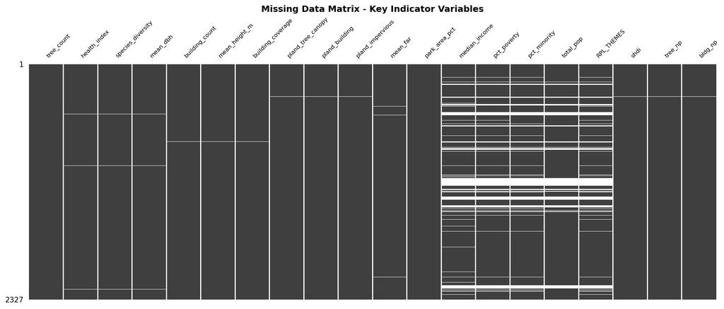

```
Saved missing_data_matrix.png
```

```python
# Missingness visualization
key_vars = ['tree_count', 'health_index', 'species_diversity', 'mean_dbh',
            'building_count', 'mean_height_m', 'building_coverage',
            'pland_tree_canopy', 'pland_building', 'pland_impervious',
            'mean_far', 'park_area_pct',
            'median_income', 'pct_poverty', 'pct_minority', 'total_pop',
            'RPL_THEMES', 'shdi', 'tree_np', 'bldg_np']
available_vars = [v for v in key_vars if v in master.columns]

fig, ax = plt.subplots(figsize=(14, 6))
msno.matrix(master[available_vars].reset_index(drop=True), ax=ax, fontsize=8, sparkline=False)
ax.set_title('Missing Data Matrix - Key Indicator Variables', fontsize=12, fontweight='bold')
plt.tight_layout()
plt.savefig(VIS + 'missing_data_matrix.png', dpi=150, bbox_inches='tight')
plt.show()
print('Saved missing_data_matrix.png')
```

## 11. Initial Results & Visualizations

```python
# Reload trees for borough-level charts
trees_clean = pd.read_csv(PROCESSED + 'trees_cleaned.csv', low_memory=False)
# Fix borough column from spatial join
if 'borough' not in trees_clean.columns:
    if 'borough_right' in trees_clean.columns:
        trees_clean = trees_clean.rename(columns={'borough_right': 'borough'})
    elif 'borough_left' in trees_clean.columns:
        trees_clean = trees_clean.rename(columns={'borough_left': 'borough'})
print(f'Trees for plotting: {len(trees_clean):,}')
```

```
Trees for plotting: 652,045
```

### Figure 1: Tree Health Index by Census Tract (Choropleth Map)

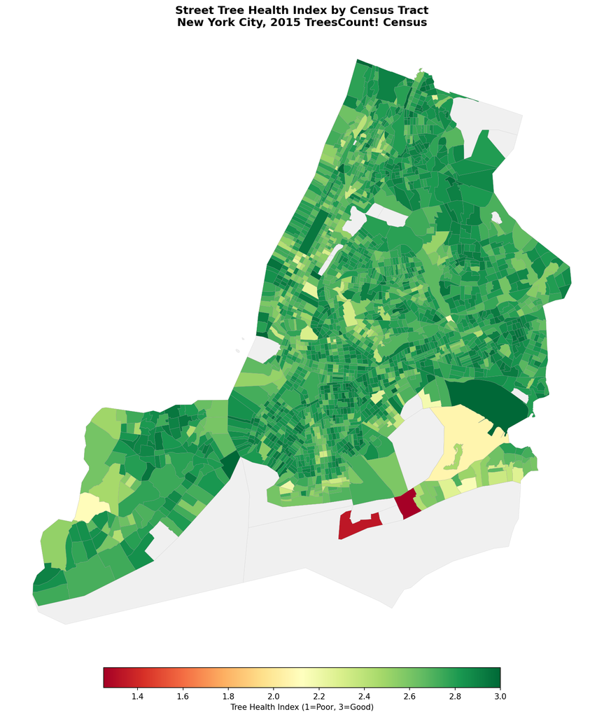

```
Saved map_tree_health_index.png
```

```python
fig, ax = plt.subplots(1, 1, figsize=(12, 14))
master_geo = gpd.GeoDataFrame(master, geometry='geometry', crs=tracts.crs)
master_geo.plot(ax=ax, color='#f0f0f0', edgecolor='#cccccc', linewidth=0.2)
has_health = master_geo[master_geo['health_index'].notna()]
has_health.plot(
    column='health_index', ax=ax, cmap='RdYlGn',
    edgecolor='#999999', linewidth=0.15, legend=True,
    legend_kwds={'label': 'Tree Health Index (1=Poor, 3=Good)',
                 'shrink': 0.6, 'orientation': 'horizontal', 'pad': 0.02}
)
ax.set_title('Street Tree Health Index by Census Tract\n'
             'New York City, 2015 TreesCount! Census', fontsize=14, fontweight='bold')
ax.set_axis_off()
plt.tight_layout()
plt.savefig(VIS + 'map_tree_health_index.png', dpi=200, bbox_inches='tight')
plt.show()
print('Saved map_tree_health_index.png')
```

### Figure 2: Tree Health Distribution by Borough

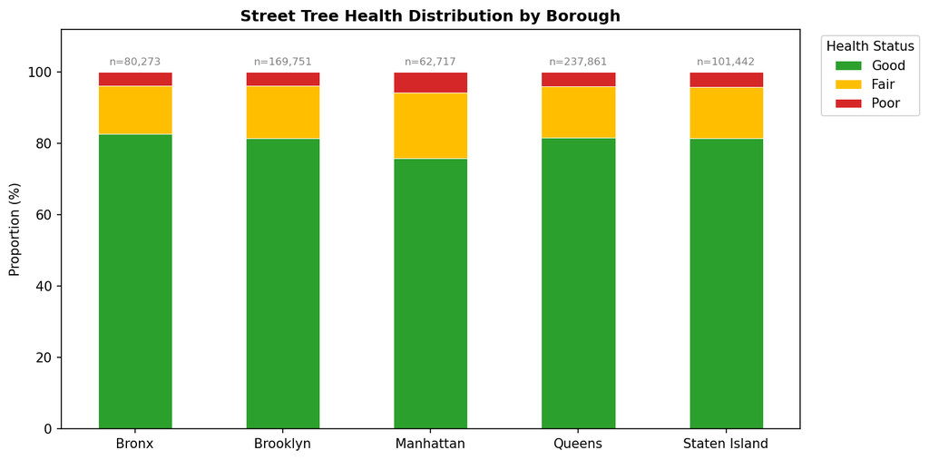

```
Saved chart_health_by_borough.png
```

```python
health_boro = trees_clean.groupby(['borough', 'health']).size().unstack(fill_value=0)
health_boro_pct = health_boro.div(health_boro.sum(axis=1), axis=0) * 100
health_boro_pct = health_boro_pct[['Good', 'Fair', 'Poor']]

fig, ax = plt.subplots(figsize=(10, 5))
health_boro_pct.plot(kind='bar', stacked=True, ax=ax,
                     color=['#2ca02c', '#ffbf00', '#d62728'], edgecolor='white', linewidth=0.5)
ax.set_ylabel('Proportion (%)')
ax.set_xlabel('')
ax.set_title('Street Tree Health Distribution by Borough', fontweight='bold')
ax.legend(title='Health Status', bbox_to_anchor=(1.02, 1), loc='upper left')
ax.set_xticklabels(ax.get_xticklabels(), rotation=0)
for i, boro in enumerate(health_boro_pct.index):
    total = health_boro.loc[boro].sum()
    ax.text(i, 102, f'n={total:,}', ha='center', fontsize=8, color='gray')
ax.set_ylim(0, 112)
plt.tight_layout()
plt.savefig(VIS + 'chart_health_by_borough.png', dpi=150, bbox_inches='tight')
plt.show()
print('Saved chart_health_by_borough.png')
```

### Figure 3: Top 15 Street Tree Species

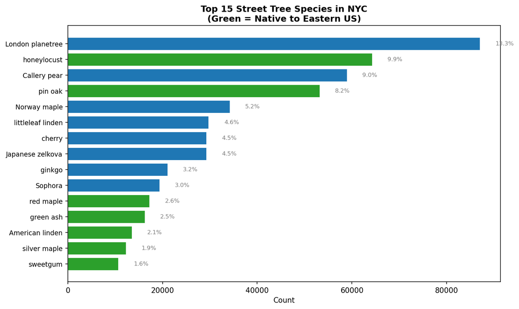

```
Saved chart_top15_species.png
```

```python
native_species = {
    'London planetree': False, 'honeylocust': True, 'pin oak': True, 'red maple': True,
    'Norway maple': False, 'green ash': True, 'American linden': True, 'silver maple': True,
    'sweetgum': True, 'ginkgo': False, 'cherry': False, 'Callery pear': False,
    'littleleaf linden': False, 'Japanese zelkova': False, 'Sophora': False,
}
top15 = trees_clean['spc_common'].value_counts().head(15)
colors = ['#2ca02c' if native_species.get(sp, False) else '#1f77b4' for sp in top15.index]

fig, ax = plt.subplots(figsize=(10, 6))
ax.barh(range(len(top15)), top15.values, color=colors, edgecolor='white', linewidth=0.5)
ax.set_yticks(range(len(top15)))
ax.set_yticklabels(top15.index, fontsize=9)
ax.invert_yaxis()
ax.set_xlabel('Count')
ax.set_title('Top 15 Street Tree Species in NYC\n(Green = Native to Eastern US)', fontweight='bold')
total = len(trees_clean)
for i, (sp, cnt) in enumerate(top15.items()):
    ax.text(cnt + total * 0.005, i, f'{cnt/total*100:.1f}%', va='center', fontsize=8, color='gray')
plt.tight_layout()
plt.savefig(VIS + 'chart_top15_species.png', dpi=150, bbox_inches='tight')
plt.show()
print('Saved chart_top15_species.png')
```

### Figure 4: Tree Density vs. Median Household Income

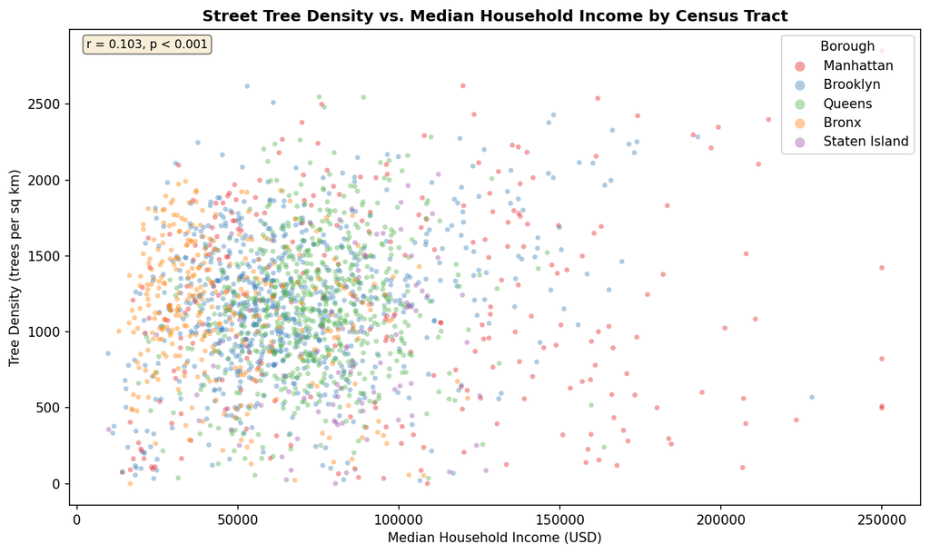

```
Saved chart_density_vs_income.png
```

```python
plot_df = master.dropna(subset=['tree_density', 'median_income'])
plot_df = plot_df[plot_df['median_income'] > 0]

fig, ax = plt.subplots(figsize=(10, 6))
for boro, color in BOROUGH_COLORS.items():
    subset = plot_df[plot_df['borough'] == boro]
    ax.scatter(subset['median_income'], subset['tree_density'],
              alpha=0.4, s=15, c=color, label=boro, edgecolors='none')
valid = plot_df[['median_income', 'tree_density']].dropna()
r, p = pearsonr(valid['median_income'], valid['tree_density'])
ptext = 'p < 0.001' if p < 0.001 else f'p = {p:.3f}'
ax.text(0.02, 0.98, f'r = {r:.3f}, {ptext}', transform=ax.transAxes, va='top',
        fontsize=9, bbox=dict(boxstyle='round', facecolor='wheat', alpha=0.5))
ax.set_xlabel('Median Household Income (USD)')
ax.set_ylabel('Tree Density (trees per sq km)')
ax.set_title('Street Tree Density vs. Median Household Income by Census Tract', fontweight='bold')
ax.legend(title='Borough', markerscale=2)
plt.tight_layout()
plt.savefig(VIS + 'chart_density_vs_income.png', dpi=150, bbox_inches='tight')
plt.show()
print('Saved chart_density_vs_income.png')
```

### Figure 5: UrbanWatch Land Cover Composition by Borough

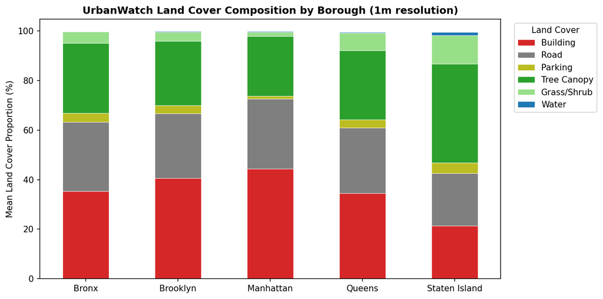

```
Saved chart_landcover_by_borough.png
```

```python
lc_cols = ['pland_building', 'pland_road', 'pland_parking',
           'pland_tree_canopy', 'pland_grass_shrub', 'pland_water']
lc_labels = ['Building', 'Road', 'Parking', 'Tree Canopy', 'Grass/Shrub', 'Water']
lc_colors = ['#d62728', '#7f7f7f', '#bcbd22', '#2ca02c', '#98df8a', '#1f77b4']

lc_by_boro = master.groupby('borough')[lc_cols].mean()
fig, ax = plt.subplots(figsize=(10, 5))
lc_by_boro.plot(kind='bar', stacked=True, ax=ax, color=lc_colors, edgecolor='white', linewidth=0.5)
ax.set_ylabel('Mean Land Cover Proportion (%)')
ax.set_xlabel('')
ax.set_title('UrbanWatch Land Cover Composition by Borough (1m resolution)', fontweight='bold')
ax.legend(labels=lc_labels, title='Land Cover', bbox_to_anchor=(1.02, 1), loc='upper left')
ax.set_xticklabels(ax.get_xticklabels(), rotation=0)
plt.tight_layout()
plt.savefig(VIS + 'chart_landcover_by_borough.png', dpi=150, bbox_inches='tight')
plt.show()
print('Saved chart_landcover_by_borough.png')
```

### Figure 6: Building Height vs. Tree Health Index

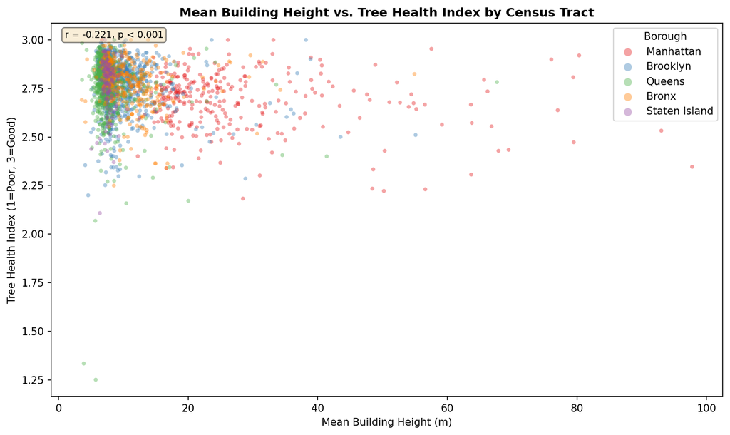

```
Saved chart_bldgheight_vs_health.png
```

```python
plot_df2 = master.dropna(subset=['mean_height_m', 'health_index'])

fig, ax = plt.subplots(figsize=(10, 6))
for boro, color in BOROUGH_COLORS.items():
    subset = plot_df2[plot_df2['borough'] == boro]
    ax.scatter(subset['mean_height_m'], subset['health_index'],
              alpha=0.4, s=15, c=color, label=boro, edgecolors='none')
valid2 = plot_df2[['mean_height_m', 'health_index']].dropna()
r2, p2 = pearsonr(valid2['mean_height_m'], valid2['health_index'])
ptext2 = 'p < 0.001' if p2 < 0.001 else f'p = {p2:.3f}'
ax.text(0.02, 0.98, f'r = {r2:.3f}, {ptext2}', transform=ax.transAxes, va='top',
        fontsize=9, bbox=dict(boxstyle='round', facecolor='wheat', alpha=0.5))
ax.set_xlabel('Mean Building Height (m)')
ax.set_ylabel('Tree Health Index (1=Poor, 3=Good)')
ax.set_title('Mean Building Height vs. Tree Health Index by Census Tract', fontweight='bold')
ax.legend(title='Borough', markerscale=2)
plt.tight_layout()
plt.savefig(VIS + 'chart_bldgheight_vs_health.png', dpi=150, bbox_inches='tight')
plt.show()
print('Saved chart_bldgheight_vs_health.png')
```

## 12. Summary Statistics

```python
print('=' * 70)
print('SUMMARY STATISTICS')
print('=' * 70)
print(f'\nSpatial units: {len(master)} Census Tracts across 5 boroughs')
print(f'Total alive street trees: {int(master["tree_count"].sum()):,}')
print(f'Mean tree density: {master["tree_density"].mean():.0f} trees/km2 '
      f'(median: {master["tree_density"].median():.0f})')
print(f'Mean Tree Health Index: {master["health_index"].mean():.2f} '
      f'(range: {master["health_index"].min():.2f} - {master["health_index"].max():.2f})')
print(f'Mean species diversity (Shannon): {master["species_diversity"].mean():.2f}')

print('\nBy Borough:')
boro_summary = master.groupby('borough').agg(
    tracts=('GEOID', 'count'),
    trees=('tree_count', 'sum'),
    density=('tree_density', 'mean'),
    health=('health_index', 'mean'),
    diversity=('species_diversity', 'mean'),
    income=('median_income', 'median'),
    tree_canopy_pct=('pland_tree_canopy', 'mean'),
    impervious_pct=('pland_impervious', 'mean'),
).round(1)
print(boro_summary.to_string())
```

```
======================================================================
SUMMARY STATISTICS
======================================================================

Spatial units: 2327 Census Tracts across 5 boroughs
Total alive street trees: 652,045
Mean tree density: 1093 trees/km2 (median: 1114)
Mean Tree Health Index: 2.76 (range: 1.25 - 3.00)
Mean species diversity (Shannon): 2.63

By Borough:
               tracts     trees  density  health  diversity   income  tree_canopy_pct  impervious_pct
borough
Bronx             361   80273.0   1057.3     2.8        2.7  38645.5             28.2            66.9
Brooklyn          805  169751.0   1140.7     2.8        2.6  61250.0             26.0            69.9
Manhattan         310   62717.0   1147.9     2.7        2.3  92852.5             24.0            73.8
Queens            725  237861.0   1074.5     2.8        2.7  72966.0             28.0            64.2
Staten Island     126  101443.0    861.7     2.8        2.9  85399.0             39.9            46.8
```

```python
print('\n--- Notebook complete ---')
print(f'\nProcessed files in data/processed/:')
for f in sorted(os.listdir(PROCESSED)):
    fpath = os.path.join(PROCESSED, f)
    size = os.path.getsize(fpath)
    if size < 1e6:
        print(f'  {f:<45s} {size/1024:>8.0f} KB')
    else:
        print(f'  {f:<45s} {size/1e6:>8.1f} MB')

print(f'\nVisualization files in visualizations/:')
for f in sorted(os.listdir(VIS)):
    print(f'  {f}')
```

```
--- Notebook complete ---

Processed files in data/processed/:
  buildings_by_tract.csv                             264 KB
  fragstats_by_tract.csv                             299 KB
  landcover_by_tract.csv                             388 KB
  nyc_tracts.gpkg                                    2.1 MB
  parks_by_tract.csv                                  69 KB
  pluto_by_tract.csv                                 243 KB
  socioeconomic_by_tract.csv                         345 KB
  species_profiles.csv                                 0 KB
  tract_indicators_full.csv                          2.0 MB
  tract_indicators_full.gpkg                         3.3 MB
  trees_by_tract.csv                                 409 KB
  trees_cleaned.csv                                232.9 MB
  urbanwatch_classified.tif                         87.5 MB

Visualization files in visualizations/:
  chart_bldgheight_vs_health.png
  chart_density_vs_income.png
  chart_health_by_borough.png
  chart_landcover_by_borough.png
  chart_top15_species.png
  map_tree_health_index.png
  missing_data_matrix.png
```